# forestdiversity

# Installation of the package

```r
require(devtools)
devtools::install_gitlab('arnaud.guyennon/forestdiversity')
```

# Stand heterogeneity indices

A stand dataset is defined as a data.frame describing trees attributes. The dataset must contain at least these variables:

1. species names, variable name must be ‘species’
2. a size variable, usually diameter at breast height, variable name must be ‘D_cm’

Each line can represent a unique tree, or a number of trees for its species/size couple. In the latter case a variable named ‘weigth’ must give this number of trees (not necessarily an integer).

## Non spatial indices

These indices do not require tree coordinates. Heterogeneity indices can be calculated using whether species or size classes.

Two different kind of indices can be computed:

1. Hill Numbers
2. Entropy based indices

### Computation of Hill numbers

1. H0 = Number of classes (Richness)
2. H1 = exponential of the Shannon entropy index
3. H2 = inverse of the Simpson index

### Computation of entropy based indices

Indices computed are

1. Number of classes (Richness)
2. Shannon index
3. Simpson index

When the variable we used to compute indices is not species, we can also compute the Gini Index. Here the Gini index is systematically based on proportions of basal area.

### Details on indices

We note $p_i$ the proportion of class i and N the total number of classes:

1. $Nclass = N$
2. $Shannon = \sum_{i=1}^{i=N}( - p_i * log(p_i))$
3. $Simpson = \sum_{i=1}^{i=N}(p_i^2) = \dfrac{1}{H2}$

The proportion $p_i$ can be calculated using tree density (i.e. the proportion of trees in each species/size class) or basal area (i.e the proportion of basal area within each species/size class).

### Example

Here we want to compute Hill numbers for species using tree density:

```r
CalcDivIndex(PlotExample, Nvar = 'species', type = 'Density', Out='HillNb')
```

```
##      site Nclass   H1   H2
## 1: Random      5 3.94 3.53
```

N.B.: if specified, the function CalcDivIndex computes the diversity indices for each year/site/src/postThinning/postDisturbance within the dataset. Variables src stand for the source of data (i.e. observation or name of the model), postThinning and postDisturbance are variables link do disturbance scenarii. If no weights are given in the dataset, they will be set to 1.

To compute diversity indices using basal area:

```r
CalcDivIndex(PlotExample, Nvar = 'species', type = 'BA', Out='HillNb')
```

```
##      site Nclass   H1   H2
## 1: Random      5 3.96 3.56
```

To compute entropy based indices on basal area:

```r
CalcDivIndex(PlotExample, Nvar = 'species', type = 'BA', Out='Entropy')
```

```
##      site Nclass Shannon Simpson
## 1: Random      5    1.38   0.281
```

Both previous calculations can be performed on size rather than on species. In that case size must be divided into classes using the two parameter: ClassInter (size of each classes in the same unit as the size variable) and ClassIni (minimum size of the first class).

```r
CalcDivIndex(PlotExample, Nvar = 'D_cm', ClassInter=10, ClassIni=5, type = 'Density', Out='HillNb')
```

```
##      site  Gini Nclass   H1  H2
## 1: Random 0.458      8 5.67 4.8
```

```r
CalcDivIndex(PlotExample, Nvar = 'D_cm', ClassInter=10, ClassIni=5, type = 'BA', Out='HillNb')
```

```
##      site  Gini Nclass   H1   H2
## 1: Random 0.458      8 6.65 5.97
```

The function GiniPop used in CalcDivIndex can be used independently. If the argument Plot is TRUE, it will return a graph of the Lorenz curve.

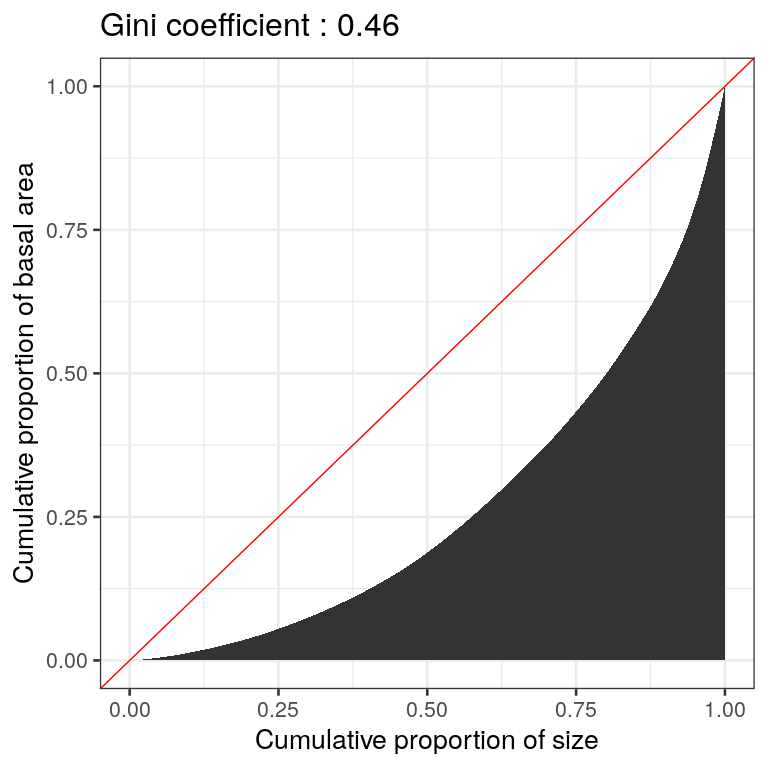

```
## [1] 0.458
```

```r
GiniPop(Size=PlotExample$D_cm, BA=PlotExample$D_cm^2, Plot=TRUE)
```

## Spatial metrics

If tree location are known in the stand, spatial heterogeneity indices can be computed. As an example, we have a dataset named PlotExample with tree species, tree diameters (D_cm), tree locations in X / Y, and tree heights (H_m):

```r
print(head(PlotExample))
```

```
##              species D_cm    X        Y   H_m   site
## 1        Picea abies 50.4 78.9 3.60e-01  5.93 Random
## 2         Abies alba 40.4 74.9 5.64e-01  8.01 Random
## 3        Picea abies 23.8 71.7 1.34e-14  8.11 Random
## 4 Fraxinus excelsior 21.4 65.2 1.29e+00 13.21 Random
## 5         Abies alba 30.9 63.0 1.07e+00  6.97 Random
## 6         Abies alba 69.8 61.7 2.96e-14 26.83 Random
```

We first need to build a TabDist object using the TabDist function:

```r
Td <- TabDist(PlotExample, coord=c(0, 80, 0, 80), shape='quadrat', Nselec=10)
```

The shape argument give the shape of the plot (‘quadrat’ or ‘circular’), by default it is ‘quadrat’ The coord argument gives the dimension of the plot:

1. if shape==‘quadrat’ : coord=(xmin, xmax, ymin, ymax) in meters
2. if shape==’circular : coord=radius (in meter)

The Nselec argument gives the number of neighboors we should consider for each tree. By default it is 10 and it is recommended to keep this value.

We can plot the TabDis object

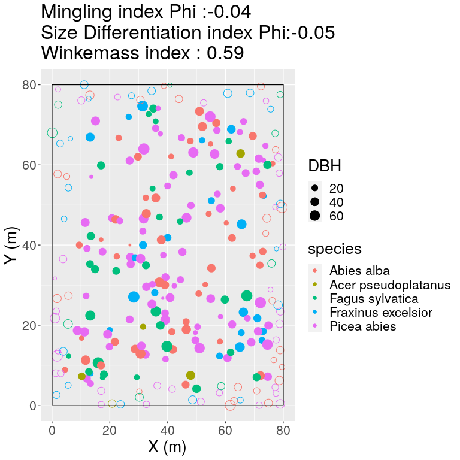

```r
plot(Td)
```

We see in the figure the trees that will be used in further calculations (i.e. not too close to the borders of the plot). Empty circles will be discarded because they are too close to the borders.

Several metrics can then be computed, for each we need to select the number of neighboors that will be used (by default 4) and the type of correction we want to apply to take into account the border effect (by default ‘NN1’).

## The mingling index

```r
Compute_mingling(Td, Nk=4, EdgeCorrection="NN1")
```

```
##       M   Em     phi
## 1 0.745 0.72 -0.0359
```

For Nk number of neighboors (by default 4) we get M the mingling index for Nk neighboors. Em is the expected mingling index in case of independent species, and does not depend on the number of neighboors. Phi is simply $1 - \frac{M}{Em}$ : if phi is 0 then species in the plot are independently organized, if phi is 1 then species seggregation is maximum, and if phi is -1 then attraction of different species is maximum.

Pommerening et al, 2017 presented their results using 3 neighboors, in IMaestro we use 4 as suggested by Aguirre (2003).

## The size differentiation index

The size differentiation index (Pommerening et al, 2017) is the “mean of the ratio of smaller and larger plant sizes u of the k nearest neighbours subtracted from one.” For each tree i, we select the k closest neighboors (by default 4, maximum equals to Nselect) and compute $T_i=\frac{1}{k}\sum_{j=1}^k \frac{min(u_i, u_j)}{max(u_i, u_j)}$ Here the size u is taken as the DBH.

```r
Compute_Size_Diff(Td, Nk=4, EdgeCorrection="NN1")
```

```
##       T    ET     phi
## 1 0.389 0.365 -0.0675
```

As in the mingling index, we also compute the expected size differentiation, which is independent of the number of neighboors, and phi as $1 - \frac{T}{ET}$.

## The Winkelmass index

Also called the Uniform angle index, “The Winkelmass describes the regularity or irregularity of the spatial distribution of the n trees nearest to a reference tree i” (Hui and Gadow, 2002). This index is based on the angle between trees and their neighboors and we refer to the paper of Hui and Gadow, 2002 for explanations. They give an interpretation to the index :

| Winkelmass | Category |
| --- | --- |
| 0 | very regular |
| 0.25 | regular |
| 0.5 | random |
| 0.75 | irregular |
| 1 | very irregular |

```r
Compute_Winkelmass(Td, Nk=4)
```

```
## [1] 0.594
```

## Structural Complexity Index

When height is filled in the dataset (variable ‘H_m’), one can compute the structural complexity index (SCI: Zenner & Hibbs 2000). SCI is defined as “the sum of the surface areas of the [triangulated irregular network] for a stand divided by the ground area covered by all triangles”. We strongly recommend the reading of Zenner & Hibbs (2000) for a better understanding of this index. The index ranges from 1 (all trees have the same height) to theoretically infinity, the higher value meaning a higher 3D heterogeneity.

```r
StructuralComplexityIndex(PlotExample, coord=c(0,80,0,80))
```

```
## [1] 3.92
```

# Recovery metrics (Resilience)

## One perturbation event

1. Time to recover
2. Degree of recovery after X years (by default X=20 years)
3. The recovery rate.
4. The efficienct at time X

Here is an example with a virtual simulation for two sites using Salem model:

```r
print(str(VirtualExperiment))
```

```
## 'data.frame':    3977 obs. of  11 variables:
##  $ site           : int  1 1 1 1 1 1 1 1 1 1 ...
##  $ year           : int  2000 2000 2000 2000 2000 2000 2000 2000 2000 2000 ...
##  $ postThinning   : Factor w/ 1 level "false": 1 1 1 1 1 1 1 1 1 1 ...
##  $ postDisturbance: Factor w/ 2 levels "false","true": 1 1 1 1 1 1 1 1 1 1 ...
##  $ species        : int  9 9 9 9 9 9 9 9 9 9 ...
##  $ D_cm           : num  21.5 13.5 28.5 27.5 31.5 24.5 20.5 32.5 23.5 12.5 ...
##  $ H_m            : num  17.5 13.9 22.1 23.8 22 ...
##  $ V_m3           : num  0.315 0.176 0.649 0.58 0.792 ...
##  $ X              : logi  NA NA NA NA NA NA ...
##  $ Y              : logi  NA NA NA NA NA NA ...
##  $ weight         : num  56.86 41.4 19.09 24.16 8.09 ...
## NULL
```

The dataset must contain informations on the perturbation, with at least the years with perturbations, and the initial state.

We first need to ‘format’ Salem outputs:

```r
DF <- format_salem(dataRaw=VirtualExperiment, ClassInter=10, ClassIni=7.5, type='BA')
```

```
##    simulationId   src Ne
## 1:            1 salem  1
## 2:            2 salem  1
```

```r
print(head(DF))
```

```
##    simulationId   src year postDisturbance V_m3   Dg   N   BA siteSize GiniSize
## 1:            1 salem 2000           FALSE  285 20.4 876 28.7        1    0.283
## 2:            1 salem 2000            TRUE  195 19.7 642 19.6        1    0.279
## 3:            1 salem 2001           FALSE  205 20.1 654 20.7        1    0.280
## 4:            1 salem 2002           FALSE  210 20.4 653 21.3        1    0.280
## 5:            1 salem 2003           FALSE  224 20.8 657 22.3        1    0.284
## 6:            1 salem 2004           FALSE  238 21.1 656 22.9        1    0.283
##    NclassSize H1Size H2Size siteSp NclassSp H1Sp H2Sp BAinc YearDisturbance
## 1:          3   2.44   2.08      1        1    1    1    NA            2000
## 2:          3   2.35   1.97      1        1    1    1    NA            2000
## 3:          3   2.39   2.02      1        1    1    1    NA            2000
## 4:          3   2.41   2.04      1        1    1    1    NA            2000
## 5:          3   2.46   2.12      1        1    1    1    NA            2000
## 6:          3   2.47   2.14      1        1    1    1    NA            2000
##    preDisturbance DisturbanceType
## 1:           TRUE           Event
## 2:          FALSE           Event
## 3:          FALSE           Event
## 4:          FALSE           Event
## 5:          FALSE           Event
## 6:          FALSE           Event
```

This function will mostly compute heterogeneity indices for each year and site. It creates a new variable called ‘preDisturbance’: it equals TRUE for every year before the disturbance. For outputs from Samsara2, one must use function format_samsara. The different format functions will produce similar data.frames that can be used in metrics calculations.

One can plot the object build by format_salem/format_samsara using plot and the name of the variable to be plotted and the time at which recovery is computed.

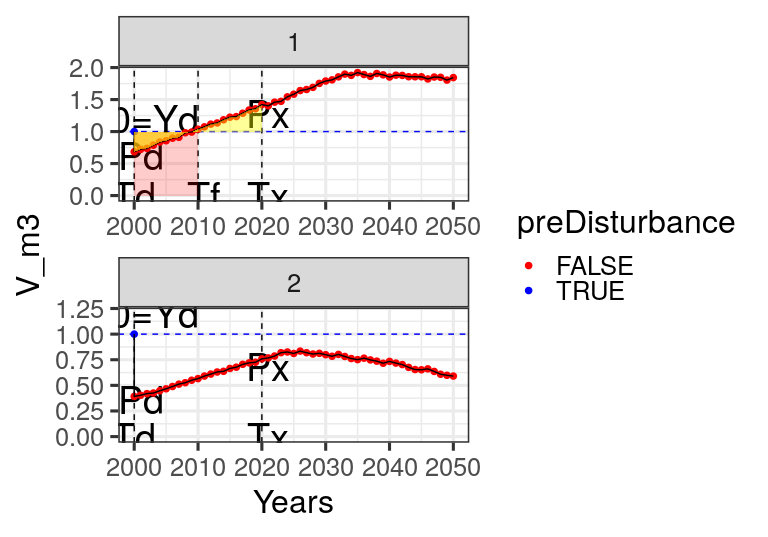

```r
plot(DF, Nvar='V_m3', RecTime=20, normalize='baseline')
```

All the metrics can be computed with normalization (see Ingrisch and Bahn, 2018 for details). The argument normalize can take three values:

1. ‘baseline’
2. ‘impact’
3. any other value will induce no normalization

The function EventResilience can then be used to compute the recovery metrics. The state before perturbation is calculated as the mean of variables over the years classified as preDisturbance==TRUE.

```r
E <- EventResilience(DF, Nvar='V_m3', RecTime=20, normalize='impact')
print(head(E))
```

```
##    simulationId   src TimeToRecover DegreeRecovery ThetaRecovery Impact  Phi1
## 1:            1 salem            10          2.338           0.1      1 0.746
## 2:            2 salem           -99          0.603         -99.0      1    NA
##    Nvar year V_m3ini Dgini Nini BAini siteSizeini GiniSizeini NclassSizeini
## 1: V_m3 2000     285  20.4  876  28.7           1       0.283             3
## 2: V_m3 2000     504  20.1 1561  49.5           2       0.270             3
##    H1Sizeini H2Sizeini siteSpini NclassSpini H1Spini H2Spini BAincini
## 1:      2.44      2.08         1           1       1       1       NA
## 2:      2.30      1.91         2           2       2       2       NA
```

Some notation explanation: TimeToRecover is the time to recovery (i.e. Tf-T0), ThetaRecovery is the recovery rate (i.e. $\frac{C0-Pd}{Tf-T0}$, DegreeRecovery is the degree of recovery after X years (the argument RecTime, here 20, i.e. $\frac{Px}{C0}$) and Phi1 the the efficiency at time X. Phi1 is computed $1 - \frac{Ax}{NCIx}$, $Ax$ being the area between the reference dynamics and 0 and $NCIx$ the net area difference between reference system (here the initial value) and perturbed system. If TimeToRecovery is -99, it means the system did not reach recovery. If any value is NA, it means that the metric could not be calculated and data should be inspected. The function EventResilience also returns the values of the population before disturbance (with the suffix “ini”).

## Regime of disturbances

For simulations with a regime of disturbations, metrics computed are:

1. Temporal instability : $CV=\frac{sd(Var)}{mean(Var)}$
2. Non Permanent Time: NPT
3. Non Permanent Intensity
4. Net change

After being formatted, the function RegimeResilience will compute the metrics.

# Landscape heterogeneity metrics

Landscape data are composed of two files, one with the gridded landscape features and one with the tree data with for each grid the trees number by dbh and species.

The function LandscapeDBHtoClass take the trees dataset and return a dbh distribution dataset. One can choose to build class with species (Arg Nvar=‘species’) or tree DBH (Arg Nvar=‘D_cm’). In the latter case the arguments ClassInter and ClassIni will define how DBH classes are built. The example object LandscapeExample has been obtained from landscape data with:

```r
DFc=LandscapeDBHtoClass(LandscapeExample, Nvar='D_cm', ClassInter=10, ClassIni=7.5)
```

```r
print(head(LandscapeExample))
```

```
##    cellID NHA BA Dg   Area XCenter YCenter Nclass_22.5 Nclass_12.5 Nclass_32.5
## 1: 904928 464 57 39 0.0625  945368 6524988           0           8           0
## 2: 904929 256 43 46 0.0625  945392 6524988           3           0           3
## 3: 904930 160 25 44 0.0625  945418 6524988           0           0           3
## 4: 904931 480 61 40 0.0625  945442 6524988           3           9           2
## 5: 904932 224 43 49 0.0625  945468 6524988           3           0           3
## 6: 904933 368 30 32 0.0625  945492 6524988           2           5          11
##    Nclass_42.5 Nclass_52.5 Nclass_82.5 Nclass_62.5 Nclass_92.5 Nclass_72.5
## 1:          15           5           0           0           0           1
## 2:           5           1           0           3           0           1
## 3:           2           5           0           0           0           0
## 4:           7           4           0           4           0           1
## 5:           2           1           1           3           0           1
## 6:           3           2           0           0           0           0
##    Nclass_102.5 Nclass_112.5 Nclass_122.5 BAclass_22.5 BAclass_12.5
```

[output cut: 27 more lines]

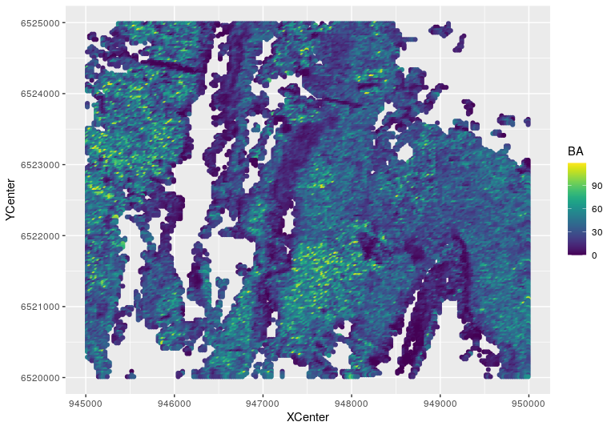

```r
ggplot2::ggplot(LandscapeExample, ggplot2::aes(x=XCenter, y=YCenter, col=BA)) + ggplot2::geom_point() + viridis::scale_color_viridis()
```

LandscapeDBHtoClass function returns a data.frame with classes based on the number of trees (Nclass…) or the basal area (BAClass…). It also computes the basal area (BA), the mean quadratic diameter (Dg), and the tree density (NHA). From this distribution dataset, it is possible to build a “gridded distribution dataset”, using the function GridLandscape. The main argument is the resolution (or more appropriately the grain) chosen to compute heterogeneity indices. This function will build a new grid with a resolution equal to Res and gather data into this new grid points.

As there is a large number of possible grid configurations, the argument N which range from 1 to 9, helps produce 9 potential grid configuration to be able to produce variability.

```r
GridData=GridLandscape(LandscapeExample, Res=.5, N=1)
print(head(GridData))
```

```
##    Iind Nclass_22.5 Nclass_12.5 Nclass_32.5 Nclass_42.5 Nclass_52.5 Nclass_82.5
## 1:  1/1       15.33       24.24        6.80        3.05       1.189      0.0945
## 2: 1/10        4.64        9.57        4.45        2.12       0.708      0.0208
## 3: 1/11        1.90        5.30        4.20        5.60       2.900      0.2000
## 4:  1/2       14.12       28.35        5.06        2.39       0.715      0.0387
## 5:  1/3       14.73       26.48        6.98        3.84       1.107      0.0201
## 6:  1/4        9.74       18.61        6.30        3.81       1.778      0.0631
##    Nclass_62.5 Nclass_92.5 Nclass_72.5 Nclass_102.5 Nclass_112.5 Nclass_122.5
## 1:       0.472     0.06299      0.2362            0            0            0
## 2:       0.380     0.00521      0.1094            0            0            0
## 3:       1.400     0.00000      0.6000            0            0            0
## 4:       0.261     0.02817      0.0599            0            0            0
## 5:       0.391     0.00000      0.1472            0            0            0
## 6:       0.823     0.01502      0.3123            0            0            0
##    BAclass_22.5 BAclass_12.5 BAclass_32.5 BAclass_42.5 BAclass_52.5
```

[output cut: 27 more lines]

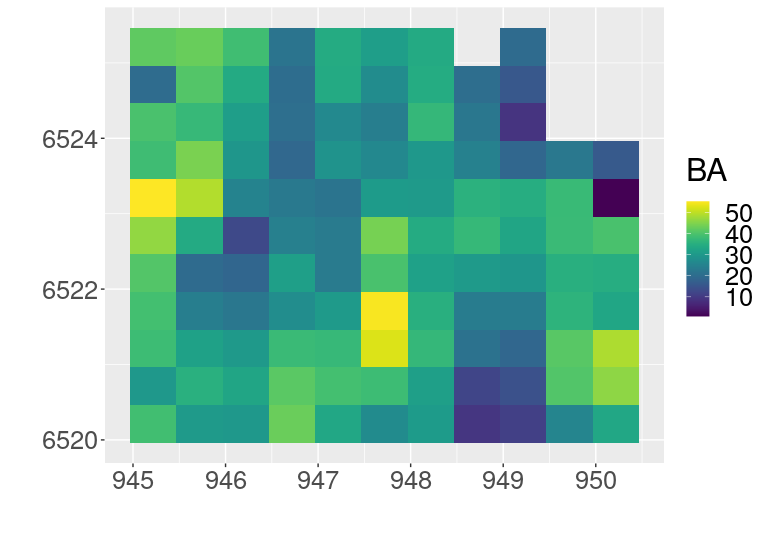

```r
plot(GridData)
```

The GridLandscape function returns a data.frame at the new resolution, and just gather the data from the distribution dataset. It also computes the quadratic mean diameter (Dg), the total basal area (BA), the tree density (NHA), the number of initial cells within each grid point (Ncells) and their area.

The function ComputeHeterogeneity will compute different heterogeneity indices from the distribution dataset (here LandscapeExample). The gridding process is performed within the function.

1. alpha/beta/gamma diversity based on Richness (Nb of class)
2. alpha/beta/gamma diversity based on shannon from proportion based on density
3. alpha/beta/gamma diversity based on shannon from proportion based on basal area
4. The coefficient of variation of the mean basal area in each grid point
5. The coefficient of variation of tree density in each grid point

For example to compute heterogeneity metrics usind GridData :

```r
ComputeHeterogeneity(GridData)
```

```
##   alphaNcl betaNcl gammaNcl alpha beta gamma alphaBA betaBA gammaBA CVBA CVNHA
## 1     9.27    1.19       11  1.42 1.02  1.45    1.89   1.02    1.93 9.03   112
##   Res
## 1 0.5
```

# Landscape biodiversity metrics

The function ComputeBuidiversity will compute, for each diversity variable in the distribution data.frame, the area weighted mean, 10 weighted percentile and 90 weighted percentiles. If variables VDW (dead wood volume), LSDTN (the density of large standing dead trees), LLTDN (the density of large living trees) are present, it will add percentage of area above already fixed thresholds.

```r
ComputeBiodiversity(GridData)
```

```
##    VDW Cover VDWP10 CoverP10 VDWP90 CoverP90 VDW20 VDW60 Variance.of.Cover
## 1 53.2  66.5   51.7       65   54.9     68.1  17.5     0              1.94
```

Both calculation can simply be performed using directly the distribution data.frame and the function ComputeHeterogeneityScale, with the wanted grain (still in km). In this case, calculation are made using the 9 grid configurations and the output is the mean of indices over these configurations.

```r
ComputeHeterogeneityScale(LandscapeExample, Res=0.05, Out='Mean')
```

```
##          alphaNcl           betaNcl          gammaNcl             alpha
##              6.31              1.74             11.00              1.31
##              beta             gamma           alphaBA            betaBA
##              1.11              1.45              1.62              1.19
##           gammaBA              CVBA             CVNHA               Res
##              1.93             15.12            245.16              0.05
##               VDW             Cover            VDWP10          CoverP10
##             53.29             66.58             34.78             42.82
##            VDWP90          CoverP90             VDW20             VDW60
##             63.84             79.90             17.22              3.62
## Variance.of.Cover
##            219.64
```

The function can be applied on several grains, by using

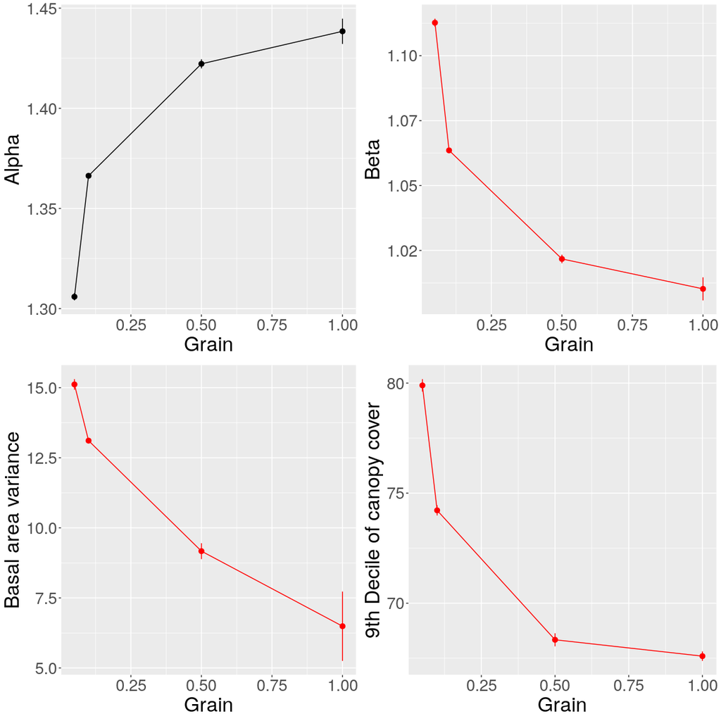

```r
DF <- ComputeHeterogeneityMultiScale(LandscapeExample, Res=c(0.05, 0.1, 0.5, 1), Plot=TRUE)
```